# report

2023-02-24

# **REPORT**

## *(2)* Identify patterns

### Load dataset

```r
library(tidyverse)
df <- read_csv("df_Morgan.csv")
#df <- df[1:100,]
```

```r
### Create product column in dataset

k=1
col=c()
for (dept in df$Department) {
  if (dept==2 || dept %in% c(101:129)){
    col[k]="Tires"
  } else if (dept==6){
    col[k]="Mechanical"
  } else if (dept==10){
    col[k]="Misc"
  } else if (dept==11){
    col[k]="Parts"
  } else {
    col[k]="Other"
  }
  k=k+1
}

df["Products"]=col
```

The database at our disposal does not contain the names of the products. So we use the department to find the products sold. So we created a new column “Products” based on the column “Department”.

### Distinguish repeat from first-time client

```r
library(dplyr)
customers <- unique(df$CustomerId)
freq = c()
i=1
for (customer in customers) {
  x <- n_distinct(subset(df, CustomerId==customer, select = TransactionId))
  freq[i]=x
  i=i+1
}
customers_freq <- data.frame(customers, freq)
```

We determine which customers are repeat customers and which are first-time customers by checking whether a customer’s ID appears in several different transactions. If yes, it is a regular customer, if not, it is a first time customer.

### Determine most product sold per customer frequence

We thus determine the most sold products by frequency of purchase of the customers.

#### *freq = 1*

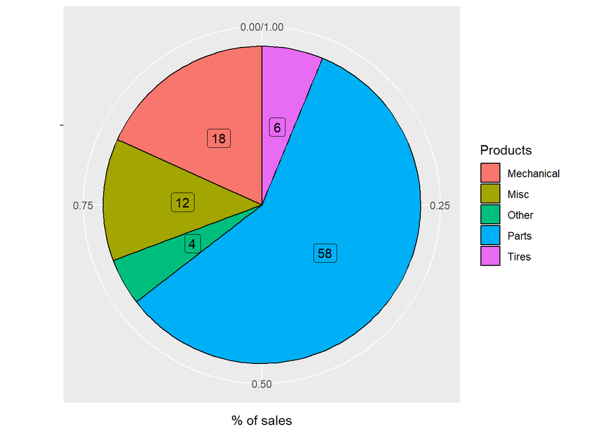

```r
library(ggplot2)

selected_customers<-subset(customers_freq, freq==1, select=customers)

filter_df_per_cus_freq <- subset(df, CustomerId %in% selected_customers$customers, select = Products)

prop_df_1<-as.data.frame(table(filter_df_per_cus_freq$Products))

colnames(prop_df_1) <- c("Products", "Percent")

total<-sum(prop_df_1$Percent)

ggplot(prop_df_1, aes(x = "", y = Percent/total, fill = Products)) +
  geom_col(color = "black") +
  geom_label(aes(label = as.integer(Percent*100/total)),
             position = position_stack(vjust = 0.5),
             show.legend = FALSE) +
  labs(y="% of sales", x="")+
  coord_polar(theta = "y")
```

We notice that the products most purchased by new customers are those coming from the “Parts” department with 58% of sales.

#### *freq in [2-5]*

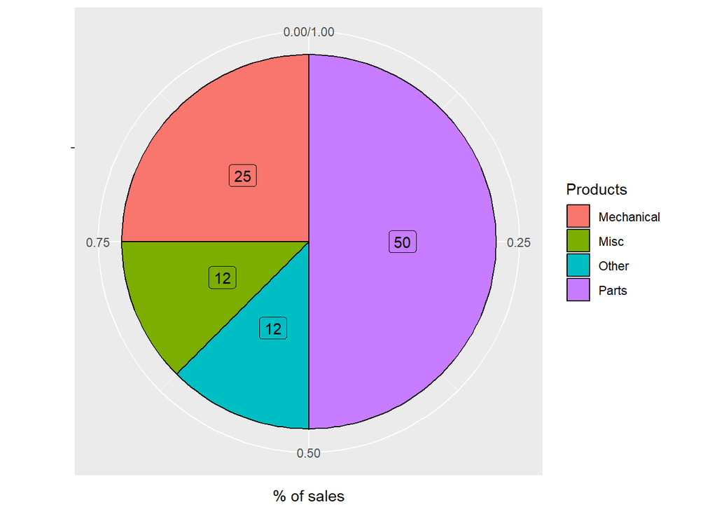

```r
library(ggplot2)

selected_customers<-subset(customers_freq, freq %in% c(2:5), select=customers)

filter_df_per_cus_freq <- subset(df, CustomerId %in% selected_customers$customers, select = Products)

prop_df_2<-as.data.frame(table(filter_df_per_cus_freq$Products))

colnames(prop_df_2) <- c("Products", "Percent")

total<-sum(prop_df_2$Percent)

ggplot(prop_df_2, aes(x = "", y = Percent/total, fill = Products)) +
  geom_col(color = "black") +
  geom_label(aes(label = as.integer(Percent*100/total)),
             position = position_stack(vjust = 0.5),
             show.legend = FALSE) +
  labs(y="% of sales", x="")+
  coord_polar(theta = "y")
```

## *(3)* Influence of the purchase of one product on others

We therefore try to analyze the influence of the purchase of a product on the purchase of others. To do this, we first identify all the transactions containing a particular product. Then we determine what is the percentage of purchase of the other products following the purchase of the studied product.

#### *for Tires*

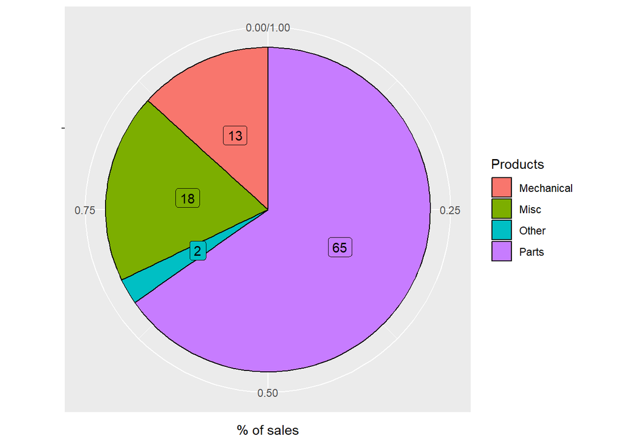

```r
Tires_transaction_df <- subset(df, Products=="Tires", select = TransactionId)

trans_prod<-subset(df, TransactionId %in% Tires_transaction_df$TransactionId, select = Products)

trans_prod <- subset(trans_prod, !(Products=="Tires"))

prop_df_3 <- as.data.frame(table(trans_prod))

colnames(prop_df_3) <- c("Products", "Percent")

total<-sum(prop_df_3$Percent)

ggplot(prop_df_3, aes(x = "", y = Percent/total, fill = Products)) +
  geom_col(color = "black") +
  geom_label(aes(label = as.integer(Percent*100/total)),
             position = position_stack(vjust = 0.5),
             show.legend = FALSE) +
  labs(y="% of sales", x="")+
  coord_polar(theta = "y")
```

#### *for Misc*

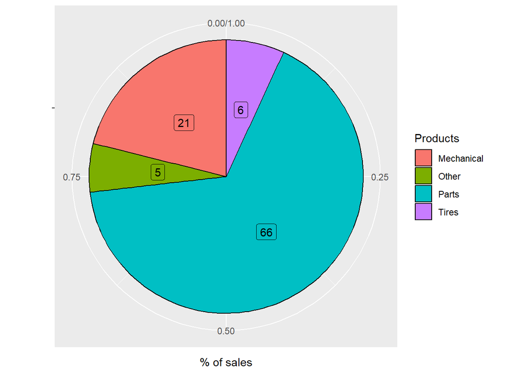

```r
Misc_transaction_df <- subset(df, Products=="Misc", select = TransactionId)

trans_prod<-subset(df, TransactionId %in% Misc_transaction_df$TransactionId, select = Products)

trans_prod <- subset(trans_prod, !(Products=="Misc"))

prop_df_4 <- as.data.frame(table(trans_prod))

colnames(prop_df_4) <- c("Products", "Percent")

total<-sum(prop_df_4$Percent)

ggplot(prop_df_4, aes(x = "", y = Percent/total, fill = Products)) +
  geom_col(color = "black") +
  geom_label(aes(label = as.integer(Percent*100/total)),
             position = position_stack(vjust = 0.5),
             show.legend = FALSE) +
  labs(y="% of sales", x="")+
  coord_polar(theta = "y")
```

#### *for Parts*

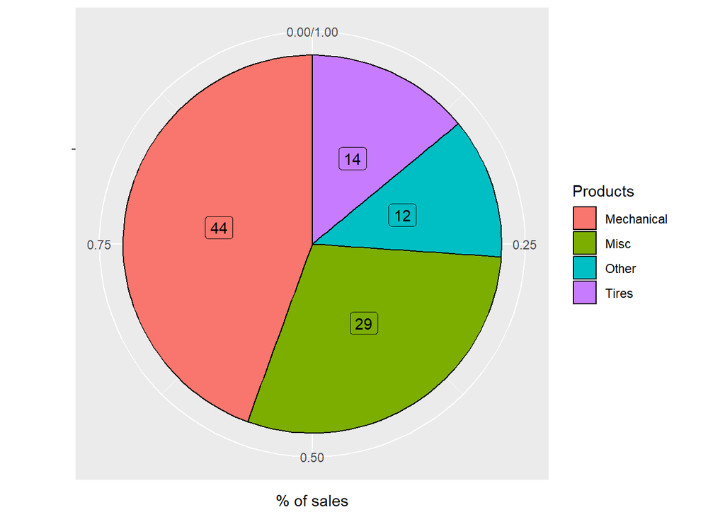

```r
Parts_transaction_df <- subset(df, Products=="Parts", select = TransactionId)

trans_prod<-subset(df, TransactionId %in% Parts_transaction_df$TransactionId, select = Products)

trans_prod <- subset(trans_prod, !(Products=="Parts"))

prop_df_5 <- as.data.frame(table(trans_prod))

colnames(prop_df_5) <- c("Products", "Percent")

total<-sum(prop_df_5$Percent)

ggplot(prop_df_5, aes(x = "", y = Percent/total, fill = Products)) +
  geom_col(color = "black") +
  geom_label(aes(label = as.integer(Percent*100/total)),
             position = position_stack(vjust = 0.5),
             show.legend = FALSE) +
  labs(y="% of sales", x="")+
  coord_polar(theta = "y")
```

#### *for Mechanical*

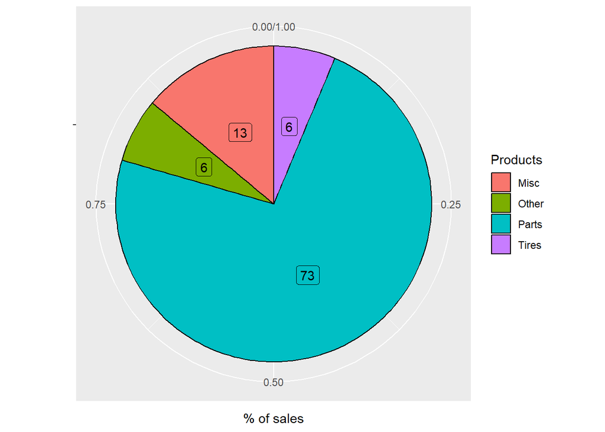

```r
Mechanical_transaction_df <- subset(df, Products=="Mechanical", select = TransactionId)

trans_prod<-subset(df, TransactionId %in% Mechanical_transaction_df$TransactionId, select = Products)

trans_prod <- subset(trans_prod, !(Products=="Mechanical"))

prop_df_6 <- as.data.frame(table(trans_prod))

colnames(prop_df_6) <- c("Products", "Percent")

total<-sum(prop_df_6$Percent)

ggplot(prop_df_6, aes(x = "", y = Percent/total, fill = Products)) +
  geom_col(color = "black") +
  geom_label(aes(label = as.integer(Percent*100/total)),
             position = position_stack(vjust = 0.5),
             show.legend = FALSE) +
  labs(y="% of sales", x="")+
  coord_polar(theta = "y")
```